# Which supermarket I should go to and when if I want to buy Monster for the cheapest price possible

## Where should I go for the cheapest Monster?

The first plot shows the **average price** at each store location in large points with individual observations as smaller jitter points. The locations are ordered from the cheapest average price on the left to most expensive on the right. The colour of the points differ by the distance of the store location from where I live. Note that locations that are “very far” from my place are excluded from all three plots, since I’m not going down to South Auckland just to buy Monster regardless of the price.

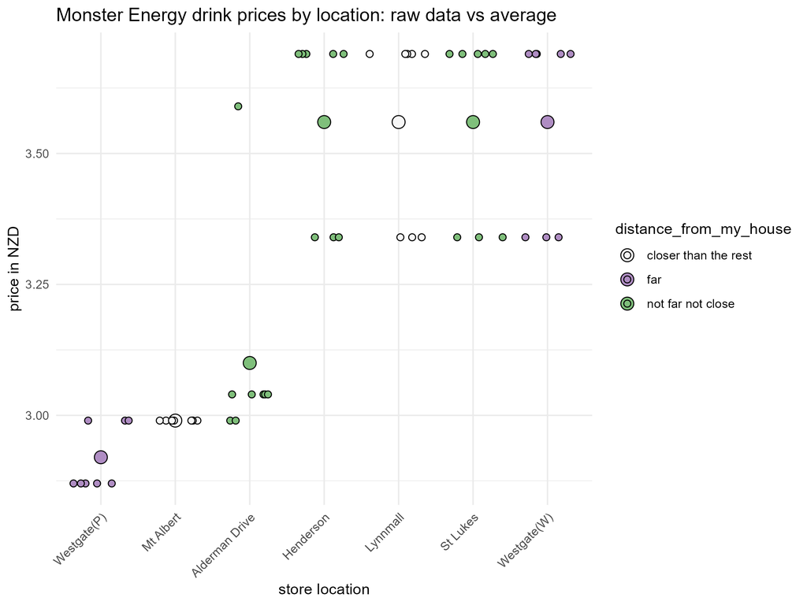

Based on the data, **Westgate (P)** has the lowest average price, followed by **Mt Albert** and **Alderman Drive**.  
The jittered points reveal that we can always trust Westgate(P) to have the cheapest Monster since its maximum price is $2.99, which is still the minimum price for both Mt Albert and Alderman Drive.

## How close is close enough?

Not every cheap store is close to home. This plot introduces a **likeability score** that combines:

- **Price** (lower = better)
- **Distance from my house** (closer = better)
- **Discount history** (extra points if the price ever dropped below $3 (2.99 is considered 3))

Discount history of going below $3 gets a bonus because I’m hoping it happens again. Bars are coloured by distance category, with borders indicating whether that location ever offered a discount below $3 (dark purple = yes, pale green = no).

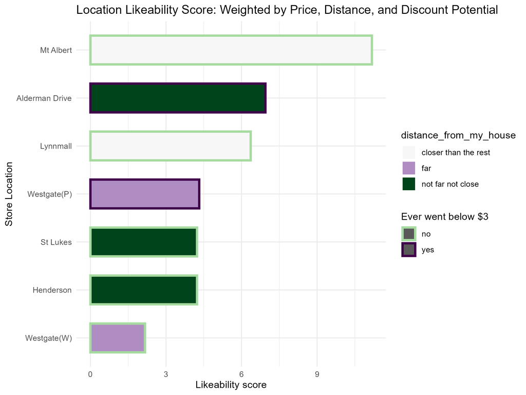

Horizontal bar chart of location likeability scores. Higher scores mean better combination of low price, short distance, and discount history.

**Mt Albert** comes first by a big gap, although its pricing never went below $3. As we can see from the first plot, Mt Albert consistently has low pricing, while also being pretty close to my place, which makes up for its poor discount history. **Alderman Drive** and **Lynnmall** also score well, with Alderman Drive being slightly more likeable than Lynnmall. Alderman Drive, like Mt Albert, has consistently shown low prices, while also having a discount history going below $3, which explains why it was able to have a higher score than Lynnmall. Lynnmall put up a good fight though, even though the discount history is not the best, but the fact that it’s closer gives it a huge upper hand. —

## When should I go?

Discounts don’t happen every day. This final plot shows the **discount rate** (proportion of visits with a discount) for each location, broken down by day of the week.

Bars are grouped by location and coloured by day.

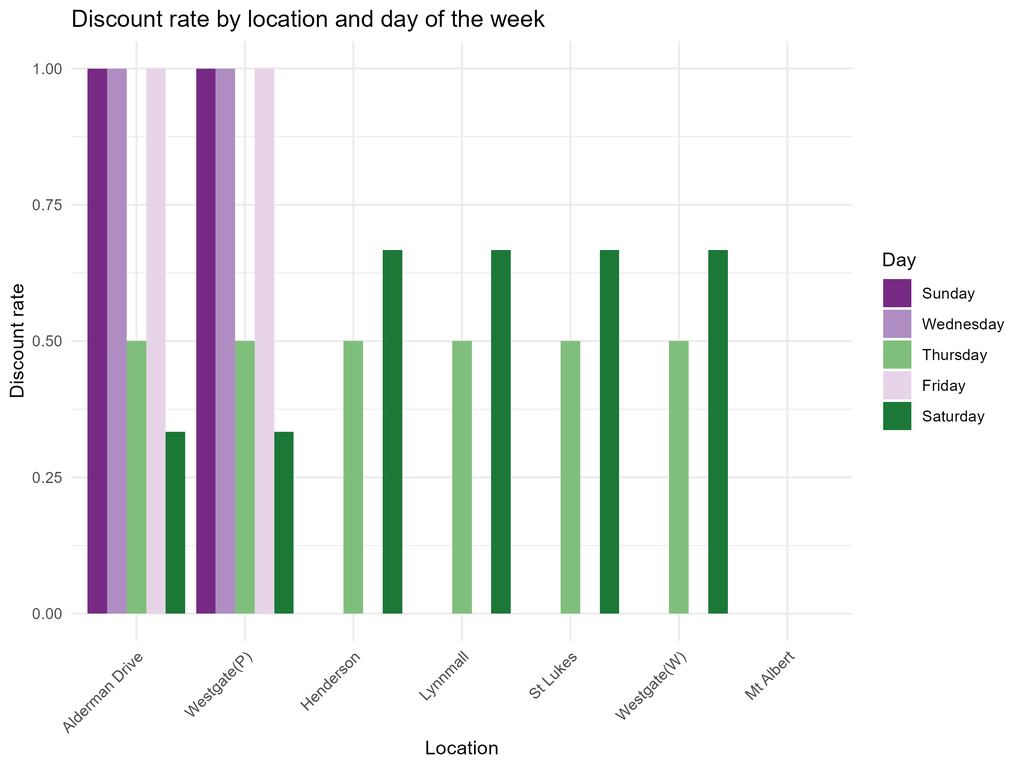

Grouped bar chart showing discount rate by location and day of the week. Taller bars mean discounts were more common on that day.

The days with the highest discount rate were Sunday, Wednesday and Friday at 100% (I do understand that this data is extreme and is caused by lack of observations). However, only Alderman Drive and Westgate(P) has discounts on those days and the rest of the locations have 0% discount rate for those dates.

It seems Saturday has a pattern where the locations that have discounts on Sunday, Wednesday and Friday have lower discount rates on Saturdays, on the other hand locations with no discounts on Sunday, Wednesday and Friday have higher discount rates for Saturday.

Mt Albert didn’t have any discounts at all so it is left blank.

Most discounts occurred on **Sunday**, **Wednesday** and **Friday**, especially at Alderman Drive and Westgate(P).  
If you want to maximise your chance of getting a discount, shop on one of these days at Alderman Drive or Westgate(P).

## The verdict

For me to get the cheapest Monster (not only the cheapest price but also the shortest time and the smallest distance to get it), I should go to:

> **Mt Albert on any day.**

Although the third plot shows that Mt Albert never had a single discount during the period of observation, the other two plots show that Mt Albert is close to my house, consistently cheap and therefore very likeable. And to be honest they do offer discounts - they just weren’t doing it when I took the data.